# Where to take this next

Our studies, Morewedge’s digital legacy project, and a re-analysis of the October open-ends

Published

November 12, 2026

## What this document is for

A place for the three of us to agree on what Pod 3 and the October study actually license, where Carey Morewedge’s unpublished work overlaps with ours, and which study to run next. It includes one new analysis: a re-coding of the 1,332 open-ended explanations from the October study, built to test whether our legacy effect runs through *his* mechanism.

# Where the project stands

```r
kable(data.frame(
  Study = c("Study 1: Future time perspective", "Study 2: Subjective knowledge",
            "Financial and EP literacy", "Extended self: qualitative pilot",
            "Classification at scale", "Posthumous value of digital goods",
            "Pod 3: digital vs. physical textbook"),
  N = c("600", "800", "372", "5", "115", "1,332", "613"),
  `One-line finding` = c(
    "Manipulation worked; no effect on information seeking",
    "Manipulation worked; no effect on intentions or expectations",
    "EP literacy is distinct from financial literacy and is the only one tied to completed actions",
    "Continuation runs through people and episodes, not legal instruments",
    "52% say meaning spans both life and after death; only 7.8% purely posthumous",
    "Legacy frame raises WTP ~38%; digital discount replicates; ownership moves with it",
    "Ownership mechanism replicates; ownership is switched off by renting"),
  check.names = FALSE), row.names = FALSE,
  caption = "Seven data collections, about 3,800 participants since January 2026.")
```

Seven data collections, about 3,800 participants since January 2026.

| Study | N | One-line finding |
| --- | --- | --- |
| Study 1: Future time perspective | 600 | Manipulation worked; no effect on information seeking |
| Study 2: Subjective knowledge | 800 | Manipulation worked; no effect on intentions or expectations |
| Financial and EP literacy | 372 | EP literacy is distinct from financial literacy and is the only one tied to completed actions |
| Extended self: qualitative pilot | 5 | Continuation runs through people and episodes, not legal instruments |
| Classification at scale | 115 | 52% say meaning spans both life and after death; only 7.8% purely posthumous |
| Posthumous value of digital goods | 1,332 | Legacy frame raises WTP ~38%; digital discount replicates; ownership moves with it |
| Pod 3: digital vs. physical textbook | 613 | Ownership mechanism replicates; ownership is switched off by renting |

Two facts organize everything below. **Thread 1’s interventions failed**: two well-powered manipulations moved their intended mediator and nothing downstream, and the only reliable predictor of intentions was prior engagement. **Thread 2’s effects are large**: the legacy frame is the biggest effect in the program, and Pod 3 shows that psychological ownership is causally switchable.

# Morewedge’s project

Presented at UCLA in late October 2026, *Egocentric Devaluation in Digital Legacy Preservation Decisions*. His abstract, verbatim:

> As user-generated content will outlive the users who create it, consumers must decide whether the digital traces of their lives on social media platforms will remain accessible after their deaths. Digital legacy decisions are intertemporal and interpersonal. Users make preservation choices today, but the primary beneficiaries are survivors who will consume the content after their deaths.

> Across seven experiments, we find that consumers value preserving the digital legacy of others more than their own. This egocentric evaluation manifests across multiple operationalizations of value, including monetary judgments, willingness to invest time, and demand for legacy preservation services. It generalizes across relationships such as partners and parents, in contexts like legal judgments and marketplace settings. We identify egocentric perspective taking as the driver. When evaluating their own content, consumers fail to recognize its value to their survivors because they focus on its lack of value to themselves. By contrast, when evaluating the value of others’ content, users focus on its consumption value to themselves and thus recognize its value to other survivors. Our findings challenge regulatory and platform assumptions that consumers, without interventions, make informed and forward-looking legacy decisions.

## How his manipulation differs from ours

**His manipulation almost certainly does not cue survivors – that is the whole point of it.** His claim is about where attention falls *naturally*. Evaluating your own digital legacy, you attend to what the content is worth to you, and the answer is not much, because you will not be there to consume it. Evaluating someone else’s, you attend to its consumption value to you – and since you are exactly the sort of person who would survive them, you can see what it is worth to a survivor. The own-versus-other contrast manipulates **whose shoes you are standing in**, not whether survivors get mentioned. Telling participants “now think about your survivors” would dismantle the very effect he is documenting.

**Ours is a different kind of manipulation, and a less clean one.** We hold the target constant – it is always your own photograph – and change what the photograph is *for*:

> you would like it to become a family keepsake that can remain with your family after your lifetime and be passed down to future generations

That sentence moves two things at once: **temporal extension** (it outlasts you) and **beneficiary salience** (named other people receive it). He isolates one thing cleanly by changing whose content it is. We move two things at once by changing what the content is for.

So our frame effect is not a verdict on his mechanism, and our manipulation carries a confound his does not. Closing that gap is what the first proposed study below is for.

# Re-analysis: what did the legacy frame move people to attend to?

Something useful is sitting unused in the October study: after entering a price, every participant wrote a few sentences. If his account is about where attention falls, then what people wrote is a reasonable place to look for it.

Two questions we can answer with data we already have:

1. **Did our legacy frame move attention toward beneficiaries at all?**
2. **If it did, is that shift what produced the +38% premium** – or did the premium also happen for people whose attention never went there?

## The question being analyzed

After the scenario and the frame manipulation, participants entered a dollar amount. The open-ended item then asked:

> In a few sentences, please explain why you would be willing to pay **the amount you entered** for the [physical / digital] photograph.

**This is a price-justification prompt, not a meaning prompt.** It asks why that number, not what the photograph means to them. That sets a low ceiling on how often *any* mechanism language appears, and it is the single most important thing to hold in mind when reading everything below.

## Method

Every explanation was scanned for two vocabularies. **Other-oriented** language names a beneficiary (children, grandchildren, heirs, descendants, future generations), a transfer (pass down, hand down, inherit, bequeath), or the posthumous period (after I die, survivors). **Self-oriented ownership** language claims possession (mine, my own, I own, keep it, hang it on my wall).

```r
tx <- tolower(d$wtp_explain)

BENEF <- paste0("\\b(child|children|kid|kids|son|sons|daughter|daughters|grandchild|",
                "grandchildren|grandkid|grandkids|grandson|granddaughter|descendant|",
                "descendants|heir|heirs|heirloom|nephew|niece|offspring|posterity|",
                "future generation|future generations|generations)\\b")
TRANSFER <- paste0("(pass(ed|ing)? (it |them )?(down|on)|hand(ed|ing)? (it )?down|",
                   "inherit(ed|ance|s)?|leave (it )?(to|behind)|left behind|bequeath)")
POSTHUM <- paste0("(after (i |i'm |im |my )(die|died|death|gone|pass)|when i die|",
                  "once i'm gone|after my lifetime|after my death|survivor)")
OWN <- paste0("\\b(mine|my own|belongs to me|i own|possess|my copy|my property|",
              "for myself|to myself|keep it|hold on to it|hold onto it|on my wall|",
              "frame it|in my home|in my house|hang it)\\b")

d$other_or <- grepl(BENEF, tx, perl = TRUE) | grepl(TRANSFER, tx, perl = TRUE) |
              grepl(POSTHUM, tx, perl = TRUE)
d$own_lang <- grepl(OWN, tx, perl = TRUE)
d$nwords   <- lengths(strsplit(tx, "[[:space:]]+"))

hc <- read.csv("wtp_explain_coding.csv", stringsAsFactors = FALSE)
m  <- merge(d, hc[, c("ResponseId", "themes")], by = "ResponseId")
agree <- mean(m$other_or == grepl("legacy", m$themes))
sens  <- mean(m$other_or[grepl("legacy", m$themes)])
```

This is an automated screen, not a substitute for hand coding. It validates reasonably against the hand coding already done: it agrees with the hand-assigned `legacy` theme on **97.6%** of responses and catches **82%** of the responses a human marked as legacy. Its real limitation is more basic: it detects *articulated* reasoning. Somebody can take their survivors’ perspective without writing it down.

## Result 1: yes, the frame moved attention toward beneficiaries

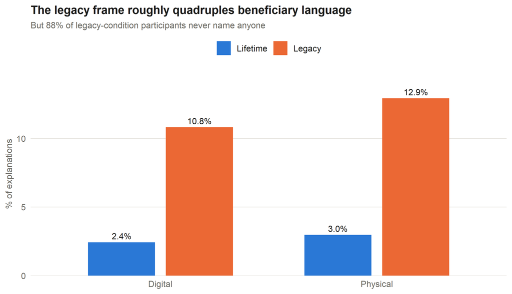

Figure 1: Share of explanations using other-oriented language, by condition. The legacy wording raises it about fourfold – but it never exceeds 13% of responses.

```r
agg <- aggregate(other_or ~ Frame + Format, d, mean)
agg$pct <- 100 * agg$other_or

ggplot(agg, aes(Format, pct, fill = Frame)) +
  geom_col(position = position_dodge(width = 0.72), width = 0.62) +
  geom_text(aes(label = sprintf("%.1f%%", pct)),
            position = position_dodge(width = 0.72), vjust = -0.5,
            size = 3.4, colour = INK) +
  scale_fill_manual(values = PAL) +
  scale_y_continuous(expand = expansion(mult = c(0, 0.15))) +
  labs(title = "The legacy frame roughly quadruples beneficiary language",
       subtitle = "But 88% of legacy-condition participants never name anyone",
       x = NULL, y = "% of explanations") +
  theme_ns()
```

**This is consistent with his account.** He argues that attention to survivors is the lever that moves valuation. Our frame pulled that lever: naming a beneficiary went from 2.7% to 11.9%. If his mechanism is real, a manipulation that quadruples beneficiary attention is exactly the kind of thing that should raise what people will pay – and ours did, by 38%.

The question is whether the one caused the other.

## Result 2: but the premium does not depend on that shift

```r
# A deliberately generous second definition: "family" as a named recipient.
# The narrow one excludes it, because "family" is in the scenario itself.
FAMRECIP <- paste0("((for|to|with|among) (my|our|the) (whole )?famil|",
                   "my famil\\w* (would|will|can|could|might|to have|to enjoy)|",
                   "share (it )?with (my|our|the) famil|available to (my|our) famil|",
                   "(my|our) famil\\w* (forever|for years|for generations))")
d$broad_or <- d$other_or | grepl(FAMRECIP, tx, perl = TRUE)

row_for <- function(keep, label) {
  s <- d[keep, ]
  mm <- tapply(s$wtp, s$Frame, mean)
  data.frame(Sample = sprintf("%s (n = %s)", label, format(nrow(s), big.mark = ",")),
             Lifetime = sprintf("$%.2f", mm[["Lifetime"]]),
             Legacy   = sprintf("$%.2f", mm[["Legacy"]]),
             `Legacy premium` = sprintf("+%.1f%%", 100 * (mm[["Legacy"]] / mm[["Lifetime"]] - 1)),
             p = format.pval(wilcox.test(wtp ~ Frame, data = s)$p.value, digits = 2),
             check.names = FALSE)
}
kable(rbind(
  row_for(rep(TRUE, nrow(d)), "Everyone"),
  row_for(!d$other_or, "Removing everyone who named a beneficiary"),
  row_for(!d$broad_or, "Also removing anyone who cast family as recipients")
), row.names = FALSE,
caption = "The legacy premium survives removing the people whose attention demonstrably went to beneficiaries.")
```

The legacy premium survives removing the people whose attention demonstrably went to beneficiaries.

| Sample | Lifetime | Legacy | Legacy premium | p |
| --- | --- | --- | --- | --- |
| Everyone (n = 1,332) | $30.68 | $44.16 | +43.9% | 5.6e-10 |
| Removing everyone who named a beneficiary (n = 1,235) | $30.77 | $42.55 | +38.3% | 6.8e-07 |
| Also removing anyone who cast family as recipients (n = 1,200) | $30.76 | $41.81 | +35.9% | 1.4e-06 |

```r
sub <- d[!d$other_or, ]; s <- tapply(sub$wtp, sub$Frame, mean)
w_sub <- wilcox.test(wtp ~ Frame, data = sub)$p.value
```

**Take out everyone whose attention demonstrably went to beneficiaries, and the premium is still there.** It drops from +43.9% to +38.3% among the 1,235 who never named one, and to +35.9% under a deliberately generous definition that also counts anyone who cast their family as recipients. Both remain significant at *p* < .00001.

This is not conclusive – people can attend to something without writing it down, and the prompt asked about price, not meaning. But it does suggest the legacy premium **does not depend on people trading off benefits to others against benefits to themselves.** Something else in the frame is doing most of the work.

## What the other 1,235 talked about instead

They answered the question they were asked: mostly about price.

```r
m2 <- merge(d, hc[, c("ResponseId", "themes", "quality")], by = "ResponseId")
sub2 <- subset(m2, !other_or)
TH <- c("price_norms", "professional_quality", "sentimental", "free_alternative",
        "printing", "format_preference", "durability", "sharing_cost", "uncertainty")
NICE <- c("Price norms and fairness", "Professional quality and effort",
          "Sentiment, memories, rare occasion", "Could get it free myself",
          "Printing", "Format preference", "Durability and permanence",
          "Splitting the cost", "Doesn't know typical prices")

rows <- do.call(rbind, lapply(seq_along(TH), function(i) {
  has <- grepl(TH[i], sub2$themes)
  lt <- has[sub2$value_frame == "lifetime"]; lg <- has[sub2$value_frame == "legacy"]
  data.frame(Theme = NICE[i],
             Overall  = sprintf("%.1f%%", 100 * mean(has)),
             Lifetime = sprintf("%.1f%%", 100 * mean(lt)),
             Legacy   = sprintf("%.1f%%", 100 * mean(lg)),
             p = format.pval(chisq.test(table(sub2$value_frame, has))$p.value, digits = 2))
}))
kable(rows[order(-as.numeric(sub("%", "", rows$Overall))), ], row.names = FALSE,
      caption = "Hand-coded themes among the 1,235 who never named a beneficiary. Responses can carry more than one theme.")
```

Hand-coded themes among the 1,235 who never named a beneficiary. Responses can carry more than one theme.

| Theme | Overall | Lifetime | Legacy | p |
| --- | --- | --- | --- | --- |
| Price norms and fairness | 51.3% | 49.8% | 52.8% | 0.33 |
| Professional quality and effort | 35.0% | 32.6% | 37.6% | 0.07 |
| Sentiment, memories, rare occasion | 32.7% | 36.4% | 28.6% | 0.0043 |
| Could get it free myself | 12.2% | 12.0% | 12.4% | 0.9 |
| Printing | 10.0% | 11.1% | 8.7% | 0.19 |
| Format preference | 9.4% | 10.3% | 8.3% | 0.27 |
| Durability and permanence | 8.3% | 6.0% | 10.7% | 0.0037 |
| Splitting the cost | 5.8% | 6.5% | 5.1% | 0.37 |
| Doesn’t know typical prices | 5.1% | 4.5% | 5.8% | 0.36 |

Half of them talk about **what a photo should cost**. A third talk about the photographer’s work, a third about sentiment. Given the prompt asked why *that amount*, this is what a well-behaved sample looks like – 94.7% were coded `ok` quality, averaging 28 words.

### What the themes actually mean

Real responses, selected only for being short enough to quote:

```r
kable(data.frame(
  Theme = c("Price norms and fairness", "Professional quality and effort",
            "Sentiment, memories, rare occasion", "Durability and permanence",
            "Could get it free myself", "Printing"),
  `What it covers` = c(
    "What photos normally cost, fairness, budget",
    "The photographer's skill, equipment, labour; paying for craft",
    "Memories, cherishing it, a rare occasion, family togetherness",
    "Lasting, fading, loss, storage, backups, 'forever'",
    "Could take the photo themselves, phone cameras",
    "Printing costs, needing to print it"),
  `Example response` = c(
    "\"I just feel like that is a normal price for a single photo. I know I would have already paid for the shoot in general.\"",
    "\"I think it is a fair price that reflects how much I value it and the effort that the photographer put into it.\"",
    "\"This photo is important to me. It will be cherished for years to come. It includes many members of my family.\"",
    "\"I want something that will last.\"",
    "\"I don't think a digital photograph should cost that much, especially when it's something I could produce myself for free.\"",
    "\"Because it is only digital. I will need to pay to print copies.\""),
  check.names = FALSE), row.names = FALSE)
```

| Theme | What it covers | Example response |
| --- | --- | --- |
| Price norms and fairness | What photos normally cost, fairness, budget | “I just feel like that is a normal price for a single photo. I know I would have already paid for the shoot in general.” |
| Professional quality and effort | The photographer’s skill, equipment, labour; paying for craft | “I think it is a fair price that reflects how much I value it and the effort that the photographer put into it.” |
| Sentiment, memories, rare occasion | Memories, cherishing it, a rare occasion, family togetherness | “This photo is important to me. It will be cherished for years to come. It includes many members of my family.” |
| Durability and permanence | Lasting, fading, loss, storage, backups, ‘forever’ | “I want something that will last.” |
| Could get it free myself | Could take the photo themselves, phone cameras | “I don’t think a digital photograph should cost that much, especially when it’s something I could produce myself for free.” |
| Printing | Printing costs, needing to print it | “Because it is only digital. I will need to pay to print copies.” |

### The frame still shifted what they talked about

Among people who never named a beneficiary, the legacy condition talked **less about sentiment** (36.4% to 28.6%, *p* = .004) and **more about durability** (6.0% to 10.7%, *p* = .004), with professional quality marginally up (32.6% to 37.6%, *p* = .07). Price talk did not move at all.

**This is not a crowding-out artifact.** Legacy and lifetime responses contain the same number of themes (1.73 vs. 1.69, *p* = .44) and the same number of words (28.5 vs. 27.9, *p* = .49), and the sentiment drop survives controlling for both (*b* = -0.42, *p* = .001). People are not saying less; they are saying something different.

**What changes is whether the photo is an experience or an artifact.** The clearest way to see it is that durability talk means different things in the two conditions:

> **Lifetime:** “It is a memory that I will have forever.”

> **Legacy:** “I’d want to make sure that it’s digitally saved to a cloud where it can be stored indefinitely.” / “Hard copies can be lost especially in moves.” / “a professional family photograph to be kept as a keepsake for many years”

Under the lifetime frame, what has to last is **your memory**. Under the legacy frame, what has to last is **the file or the print**. The object acquires a job, and once it has a job, craftsmanship matters more (professional quality up) while your personal attachment to it matters less (sentiment down).

**A third reading worth sitting with.** The sentiment drop may be the same thing the Likert data already showed: in the October study the legacy frame *lowered* psychological ownership for the physical photo (6.42 to 6.22). If framing a photo as the family’s keepsake makes it less *yours*, you would expect both less personal sentiment in the text and less reported ownership on the scale. Two different measures pointing the same way is modest evidence, but it is the kind we can build on – and none of it is about trading your benefit against a survivor’s.

## Result 3: naming a beneficiary only goes with paying more when the frame cued it

Some people name a beneficiary in **both** conditions – 79 under the legacy frame and 18 under the lifetime frame. Far fewer under lifetime, naturally, because nothing there cued it; those 18 brought it up on their own.

So: among the people who *did* name a beneficiary, do they pay more?

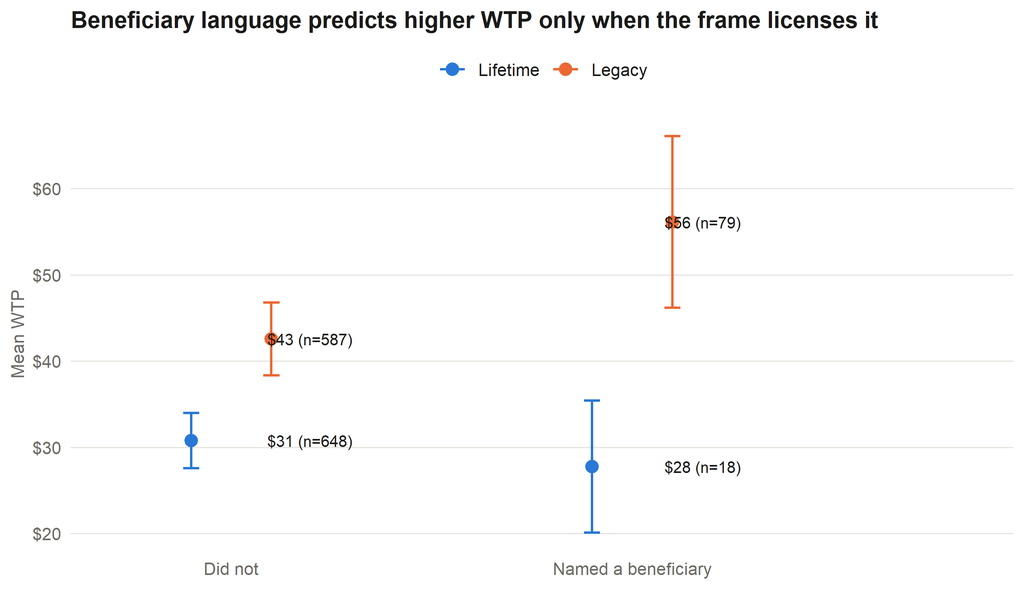

Figure 2: Mean WTP by frame and whether the explanation named a beneficiary, with 95% CIs. Under the lifetime frame, spontaneous beneficiary language is associated with slightly lower WTP. Under the legacy frame it is associated with much higher WTP.

```r
ci <- do.call(rbind, lapply(split(d, list(d$Frame, d$other_or)), function(x) {
  tt <- t.test(x$wtp)
  data.frame(Frame = x$Frame[1],
             Lang = ifelse(x$other_or[1], "Named a beneficiary", "Did not"),
             m = mean(x$wtp), lo = tt$conf.int[1], hi = tt$conf.int[2], n = nrow(x))
}))

ggplot(ci, aes(Lang, m, colour = Frame)) +
  geom_errorbar(aes(ymin = lo, ymax = hi), width = 0.08, linewidth = 0.7,
                position = position_dodge(width = 0.4)) +
  geom_point(size = 3, position = position_dodge(width = 0.4)) +
  geom_text(aes(label = sprintf("$%.0f (n=%d)", m, n)),
            position = position_dodge(width = 0.4), hjust = -0.42,
            size = 3.2, colour = INK, show.legend = FALSE) +
  scale_colour_manual(values = PAL) +
  scale_y_continuous(labels = scales::dollar) +
  scale_x_discrete(expand = expansion(add = c(0.4, 0.95))) +
  labs(title = "Beneficiary language predicts higher WTP only when the frame licenses it",
       x = NULL, y = "Mean WTP") +
  theme_ns()
```

```r
lt <- subset(d, Frame == "Lifetime"); lg <- subset(d, Frame == "Legacy")
m2 <- lm(log(wtp + 1) ~ other_or + nwords, data = lg)
kable(data.frame(
  Frame = c("Lifetime", "Legacy"),
  `Named a beneficiary` = sprintf("$%.2f", c(mean(lt$wtp[lt$other_or]), mean(lg$wtp[lg$other_or]))),
  `Did not` = sprintf("$%.2f", c(mean(lt$wtp[!lt$other_or]), mean(lg$wtp[!lg$other_or]))),
  `Wilcoxon p` = c(format.pval(wilcox.test(wtp ~ other_or, data = lt)$p.value, digits = 2),
                   format.pval(wilcox.test(wtp ~ other_or, data = lg)$p.value, digits = 2)),
  check.names = FALSE), row.names = FALSE,
  caption = "Beneficiary language and WTP, within each frame.")
```

Beneficiary language and WTP, within each frame.

| Frame | Named a beneficiary | Did not | Wilcoxon p |
| --- | --- | --- | --- |
| Lifetime | $27.78 | $30.77 | 0.34 |
| Legacy | $56.11 | $42.55 | 1.7e-05 |

**Under the legacy frame: yes, a lot.** $56 against $43, and it holds controlling for how long the response was (*b* = +0.41, *p* = 7e-04; longer answers do contain more of this language, so the control matters).

**Under the lifetime frame: no.** $28 against $31 – if anything slightly less.

Put plainly: **attending to beneficiaries is not a personal tendency that raises what someone will pay.** It only goes with paying more when the frame has already told them the photo is *for* those people. If individual differences in perspective taking drove valuation, the 18 people who spontaneously thought about their family under the lifetime frame should have paid more. They did not.

**The honest caveat is that cell size: 18 people.** Treat this as suggestive, not as a result. It is, though, the only place in the study where beneficiary attention arises without being prompted, which is what makes it worth looking at at all – and a reason to design the next study so that cell is not an accident.

## What the re-analysis licenses, and what it does not

**It licenses this:** our legacy effect is not visibly a perspective-taking effect. It survives intact among the 88% who never mention a beneficiary, and beneficiary language is inert in the condition where it arises spontaneously.

**It does not license this:** concluding his mechanism is absent. Two reasons, and the first is the serious one. The prompt asked why participants entered *that dollar amount*, so price talk crowds out everything else by design – low rates of beneficiary language are partly an artifact of the question. And a text measure sees only stated reasoning; someone can take their survivors’ perspective without writing it down.

The honest summary is that our effect is *not carried by articulated other-regard*, and that the frame visibly shifted people toward durability and away from sentiment. That is enough reason to run the explicit test rather than assume we are inside his paper – and it is a reason to ask the mechanism question directly next time, rather than hoping a price-justification prompt will reveal it.

```r
kable(data.frame(
  Frame = c("Lifetime", "Legacy"),
  `Ownership language` = sprintf("%.1f%%", 100 * c(mean(lt$own_lang), mean(lg$own_lang))),
  `WTP, used it` = sprintf("$%.2f", c(mean(lt$wtp[lt$own_lang]), mean(lg$wtp[lg$own_lang]))),
  `WTP, did not` = sprintf("$%.2f", c(mean(lt$wtp[!lt$own_lang]), mean(lg$wtp[!lg$own_lang]))),
  check.names = FALSE), row.names = FALSE,
  caption = "Ownership language is too rare in the open-ends to carry an analysis.")
```

Ownership language is too rare in the open-ends to carry an analysis.

| Frame | Ownership language | WTP, used it | WTP, did not |
| --- | --- | --- | --- |
| Lifetime | 4.7% | $21.77 | $31.12 |
| Legacy | 2.9% | $37.37 | $44.36 |

One null worth recording: ownership language appears in under 5% of responses and does not track WTP. The open-ends cannot test the ownership account. The Likert ownership measure can, and did – in the October study the legacy frame *lowered* ownership for the physical photo and *raised* it for the digital one (interaction *p* = .005).

# How we overlap, and where we are distinct

```r
kable(data.frame(
  Dimension = c("Mechanism", "What is manipulated", "Scope", "Outcome", "Premise about time"),
  `His account` = c(
    "Egocentric perspective taking: a judgment failure about whose value counts",
    "Target: your content vs. someone else's",
    "Digital user-generated content on platforms",
    "Stated value: money, time, service demand",
    "Preservation now, consumption by survivors after death"),
  `Ours` = c(
    "Psychological ownership: a property of the good, causally switchable (Pod 3)",
    "Frame (lifetime vs. legacy) and acquisition (buy vs. rent), target held constant",
    "Digital and physical goods, which is where the ownership account gets leverage",
    "Same, plus a route to real estate planning engagement via Thread 1",
    "52% say meaning spans both periods; only 7.8% purely posthumous"),
  check.names = FALSE), row.names = FALSE)
```

| Dimension | His account | Ours |
| --- | --- | --- |
| Mechanism | Egocentric perspective taking: a judgment failure about whose value counts | Psychological ownership: a property of the good, causally switchable (Pod 3) |
| What is manipulated | Target: your content vs. someone else’s | Frame (lifetime vs. legacy) and acquisition (buy vs. rent), target held constant |
| Scope | Digital user-generated content on platforms | Digital and physical goods, which is where the ownership account gets leverage |
| Outcome | Stated value: money, time, service demand | Same, plus a route to real estate planning engagement via Thread 1 |
| Premise about time | Preservation now, consumption by survivors after death | 52% say meaning spans both periods; only 7.8% purely posthumous |

The deepest difference is the last row. His framing treats legacy decisions as being about post-death consumption. Our classification data say people do not partition time that way. If continuation is experienced as already underway, “what will my survivors want” is not the question people are answering – and that is a premise his account does not examine.

# What to run next

## 1. Unconfound our own manipulation

Our legacy wording bundles temporal extension with beneficiary salience, so we cannot say which half produced +38%. A three-level frame separates them:

```r
kable(data.frame(
  Condition = c("Lifetime (control)", "Temporal extension only", "Beneficiary salience (current legacy wording)"),
  Wording = c("keep it for yourself and look back on it throughout your lifetime",
              "it will still exist long after your lifetime",
              "it becomes a family keepsake passed down to future generations"),
  `What it isolates` = c("--", "Outlasting you, with nobody named",
                         "Outlasting you, with recipients named"),
  check.names = FALSE), row.names = FALSE)
```

| Condition | Wording | What it isolates |
| --- | --- | --- |
| Lifetime (control) | keep it for yourself and look back on it throughout your lifetime | – |
| Temporal extension only | it will still exist long after your lifetime | Outlasting you, with nobody named |
| Beneficiary salience (current legacy wording) | it becomes a family keepsake passed down to future generations | Outlasting you, with recipients named |

If the middle condition reproduces most of the +38%, the effect is about persistence and is ours. If only the third condition does, it is about beneficiaries and sits much closer to his. **This is the study to run first: it is cheap, it is one factor, and its answer determines whether the other two studies are worth running.**

## 2. Add his factor to ours

2 (target: your photo vs. a friend’s photo) x 2 (frame: lifetime vs. legacy), measuring **both** perspective taking and psychological ownership.

- **His account predicts** a target main effect, with the legacy frame closing the gap for one’s own content specifically.
- **Ours predicts** the frame moves ownership regardless of target, and that ownership carries the effect.

Either result is diagnostic rather than confirmatory, and it reads as building on his work rather than racing it.

## 3. Move the outcome to behavior

Every one of his outcomes is stated. Thread 1 gives us an engagement outcome – whether people take actual estate planning steps – and a validated literacy instrument. A study linking digital-legacy valuation to real planning behavior would be the first to connect this effect to the decision it is supposed to explain, and it is where our two threads become one paper.

# Open questions for the three of us

1. **Does his manipulation cue survivors, or only the target?** This changes how close we are. Reading the paper or asking him settles it.
2. **Do we contact him?** We have just replicated his 2018 paper. A replication report is the lowest-risk opener and gives us a reason to be in touch before we publish anything adjacent. The alternatives are a courtesy note (says less) or a collaboration feeler (premature before we have a design).
3. **Do we hand-code a sample to check the screen above?** Two hundred responses double-coded for articulated perspective taking would tell us whether the automated result holds. Worth it only if we intend to report it.
4. **What is the paper?** The framing choice is between *“ownership, not perspective taking, explains the digital discount”* and *“people do not experience legacy as beginning at death.”* The second is more distinctive and more defensible against his work; the first is closer to our data today.